# 蛍光タンパク質によるAde4凝集体の様相の違い

MT

2020-02-12

# 1 この事例で扱うデータと統計

# 2 データの取得と読み込み

Ade4のC末端側に融合させた蛍光タンパク質の種類による、細胞内Ade4凝集体の蛍光強度の違いを検証。細胞をアデニン無しの培地に移して凝集体を形成させ、蛍光顕微鏡観察。各種凝集体の蛍光強度を計測し、csvファイルで出力。

```r
library(pacman) # パッケージをまとめてロード
p_load(tidyverse, openxlsx, readxl, ggtext, multcomp, ggsignif, knitr, nparcomp, rstatix, dunn.test)
```

計測したデータをまとめたExcelファイルを指定して読み込む。

```r
X200212_ade4_mean_intensity <- read_excel("~/Dropbox/200212_Ade4FPtag_analysis/200212_ade4_mean_intensity.xlsx",
                                          sheet = "for R")
```

データがワイド形式なのでロング形式に変換。値の入っていない行を除く。

```r
construct_intensity <- X200212_ade4_mean_intensity %>%
  gather(Construct, Mean_intensity, 1:3)

# NAのデータを除く
construct_intensity <- filter(construct_intensity, Mean_intensity !="")
```

変数Constructをファクター型に変換。値`mGFP`を基準のレベルに設定。

```r
# Constructをcharacterからfactorに変換
construct_intensity$Construct <- factor(construct_intensity$Construct)
levels(construct_intensity$Construct)
```

```
## [1] "GFP"  "mGFP" "mNG"
```

```r
# myeGFPをbase levelにする
construct_intensity$Construct <- relevel(construct_intensity$Construct, ref = "mGFP")
levels(construct_intensity$Construct) # 確認
```

```
## [1] "mGFP" "GFP"  "mNG"
```

# 3 正規性の検証

Shapiro-Wilk検定でデータの正規性を確認。ある`Construct`の値に対応する`Mean_intensity`の値の分布を`shapiro_test()`で検定するための関数`swt`を作成。

```r
# Constructの種類をベクトルとして取り出しておく
consts <- levels(construct_intensity$Construct)

swt <- function(const) {construct_intensity %>%
    filter(Construct == const) %>%
    dplyr::select(Mean_intensity) %>%
    as_vector() %>%
    shapiro_test()}
```

`lapply()`で`consts`の各要素を自作関数`swt`に入力して、計算結果をリストにまとめて出力。`sink()`で出力結果をテキストファイルに保存。

```r
swt_result <- lapply(consts, swt)
names(swt_result) <- consts  # リストの要素の名前をつける

sink("result_shapiro_test.txt")
swt_result
```

```
## $mGFP
## # A tibble: 1 × 3
##   variable statistic p.value
##   <chr>        <dbl>   <dbl>
## 1 .            0.969   0.528
##
## $GFP
## # A tibble: 1 × 3
##   variable statistic p.value
##   <chr>        <dbl>   <dbl>
## 1 .            0.966   0.447
##
## $mNG
## # A tibble: 1 × 3
##   variable statistic p.value
##   <chr>        <dbl>   <dbl>
## 1 .            0.925  0.0248
```

```r
sink()
```

`mNG`のp値が<0.05であり、正規性があるとは言い切れない。従って以後はノンパラメトリックな手法で解析。

ノンパラメトリックな分散分析にはKruskal-Wallis検定を使用する。p<0.05より`Construct`間に違いがあることが示唆された。

```r
aov_kw <- construct_intensity %>%  kruskal_test(Mean_intensity ~ Construct)
aov_kw
```

```
## # A tibble: 1 × 6
##   .y.                n statistic    df        p method
## * <chr>          <int>     <dbl> <int>    <dbl> <chr>
## 1 Mean_intensity    92      80.6     2 3.09e-18 Kruskal-Wallis
```

`mGFP`のデータを他2つと比較したいので、パラメトリックな多重検定ではDunnett testに相当する。Dunnett法のノンパラメトリック版としてSteel testで多重比較する。`nparcomp`パッケージの`nparcomp()`を使用。

```r
res_steel <- nparcomp(Mean_intensity ~ Construct, data = construct_intensity,
              asy.method = "mult.t", rounds = 3,
              type = "Dunnett", control = "mGFP", # Dunnettの場合はcontrolでbase levelを指定
              alternative = "two.sided", info = FALSE)
sink("res_steel_test.txt")
summary(res_steel)
```

```
##
##  #------------Nonparametric Multiple Comparisons for relative contrast effects----------#
##
##  - Alternative Hypothesis:  True relative contrast effect p is not equal to 1/2
##  - Estimation Method: Global Pseudo ranks
##  - Type of Contrast : Dunnett
##  - Confidence Level: 95 %
##  - Method = Multi - T with 51 DF
##
##  - Estimation Method: Pairwise rankings
##
##  #---------------------------Interpretation--------------------------------------------#
##  p(a,b) > 1/2 : b tends to be larger than a
##  #-------------------------------------------------------------------------------------#
##
##  #----Data Info-------------------------------------------------------------------------#
##   Sample Size
## 1   mGFP   29
## 2    GFP   30
## 3    mNG   33
##
##  #----Contrast--------------------------------------------------------------------------#
##            mGFP GFP mNG
## GFP - mGFP   -1   1   0
## mNG - mGFP   -1   0   1
##
##  #----Analysis--------------------------------------------------------------------------#
##        Comparison Estimator Lower Upper Statistic p.Value
## 1 p( mGFP , GFP )     0.999 0.998 1.000 1513.5419       0
## 2 p( mGFP , mNG )     0.998 0.992 1.004  195.5515       0
##
##  #----Overall---------------------------------------------------------------------------#
##   Quantile p.Value
## 1 2.302201       0
##
##  #--------------------------------------------------------------------------------------#
```

```r
sink()
```

いずれの組み合わせでも、p値は極めて小さく、有意な差があることが示唆された。

# 4 データの可視化

横軸を`Construct`、縦軸を`Mean_intensity`としてボックスプロット、各データポイントもプロット。×で平均値を示す。検定の結果も表示。

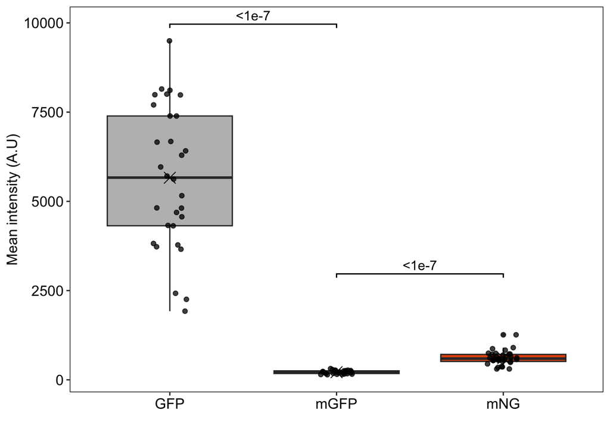

```r
plot1 <- ggplot(construct_intensity, aes (x = Construct, y =Mean_intensity)) +
  geom_boxplot(aes(fill = Construct)) +
  # 平均値の描画
  stat_summary(fun = mean, geom = "point", color = "black", shape = 4, size = 4) +
  # jitterで適当に点を散らす
  geom_jitter(size =1.5, color = 'black', alpha =0.75, height = 0, width = 0.1) +
   # 比較の組とアノテーションを直接指定して描画できる
  geom_signif(comparisons = list(c("GFP", "mGFP")), tip_length = 0.01, annotations = c("<1e-7")) +
  geom_signif(comparisons = list(c("mNG", "mGFP")), tip_length = 0.01, annotations = c("<1e-7"), y_position = 2500) +
  # x軸の並びを逆にする
  scale_x_discrete(limits=c("GFP", "mGFP", "mNG")) +
  # 手動でfillの色を指定
  scale_fill_manual(values = c('#3182bd','#bdbdbd',"#e6550d")) +
  xlab("") + # x軸ラベルに何も表示しない
  ylab("Mean intensity (A.U)") + # y軸ラベルの設定
  theme(axis.title.y = element_text(size=12), axis.text.y = element_text(size=12,color = "black"),
        axis.title.x = element_text(size=12), axis.text.x = element_text(size=12,color = "black")
        ,legend.position = "none" #凡例を消す
        ,panel.border = element_rect(fill = NA, linewidth = 0.5) # パネルを枠で囲む
        ,panel.background = element_blank()) # 背景を白にする
plot1
```